# data_selection-Copy1

#### **Descriptive Stats**

```python
for t_cnt in ["word","character"]:
    print(100*"=")
    print("\033[1m"+45*"-"+t_cnt.upper()+" COUNTS"+40*"-"+"\033[0m")
    for lan in ["German","English"]:
        print(100*"=")
        print("\033[1m"+lan+" Sentences\033[0m")
        print(100*"=")
        f_name = t_cnt+"_count_"+lan
        print("\033[1mMax "+t_cnt+"s in sentences :\033[0m",np.max(data[f_name]))
        print("\033[1mMin "+t_cnt+"s in sentences :\033[0m",np.min(data[f_name]))
        print("\033[1mAverage "+t_cnt+"s in sentences :\033[0m",int(np.average(data[f_name])))
        print("\033[1mMedian of "+t_cnt+"s in sentences :\033[0m",data[f_name].median(axis=0))
        print("\033[1mMode of "+t_cnt+"s in sentences :\033[0m",data[f_name].mode()[0])
```

```
====================================================================================================
---------------------------------------------WORD COUNTS----------------------------------------
====================================================================================================
German Sentences
====================================================================================================
Max words in sentences : 2937
Min words in sentences : 1
Average words in sentences : 21
Median of words in sentences : 19.0
Mode of words in sentences : 13
====================================================================================================
English Sentences
====================================================================================================
Max words in sentences : 4225
Min words in sentences : 1
Average words in sentences : 23
Median of words in sentences : 20.0
Mode of words in sentences : 15
====================================================================================================
---------------------------------------------CHARACTER COUNTS----------------------------------------
====================================================================================================
German Sentences
====================================================================================================
Max characters in sentences : 28383
Min characters in sentences : 1
Average characters in sentences : 152
Median of characters in sentences : 133.0
Mode of characters in sentences : 98
====================================================================================================
English Sentences
====================================================================================================
Max characters in sentences : 35861
Min characters in sentences : 1
Average characters in sentences : 138
Median of characters in sentences : 120.0
Mode of characters in sentences : 83
```

**Conclusion**

- **Word Counts - For both German and English most of the word length in sentences is around 20**
- **Character Counts - For both German and English most of the character counts in sentences are in the range 120-150**

```python
reclaim_memory()
```

```
Garbage collection thresholds: (700, 10, 10)
Garbage collector: collected 0 objects.
```

#### **Number of sentences from 1-20 words**

- Based on the above observation
  - We are calculating how many number of sentences are there from words ranging from 1-20 words

```python
df_counts=pd.DataFrame(columns =["word_count","num_sentences_German","Filter_Used_German","num_sentences_English","Filter_Used_English"])
for i in range(20):
    df_counts.loc[i,"word_count"]=i+1

    filter_="word_count_German=="+str(i+1)
    df_counts.loc[i,"Filter_Used_German"]=filter_
    df_counts.loc[i,"num_sentences_German"]=len(data.query(filter_))

    filter_="word_count_English=="+str(i+1)
    df_counts.loc[i,"Filter_Used_English"]=filter_
    df_counts.loc[i,"num_sentences_English"]=len(data.query(filter_))

df_counts.set_index("word_count").style.set_properties(**{'border': '1.3px solid black', 'color': 'black','text-align':'center'}).set_table_styles([{'selector': 'th', 'props': [('border', '1.3px solid black'),('text-align', 'center')]}]).format(precision=2)
```

| word_count | num_sentences_German | Filter_Used_German | num_sentences_English | Filter_Used_English |
| --- | --- | --- | --- | --- |
| 1 | 7691 | word_count_German==1 | 6337 | word_count_English==1 |
| 2 | 5090 | word_count_German==2 | 4627 | word_count_English==2 |
| 3 | 11339 | word_count_German==3 | 10139 | word_count_English==3 |
| 4 | 26547 | word_count_German==4 | 27246 | word_count_English==4 |
| 5 | 33457 | word_count_German==5 | 26829 | word_count_English==5 |
| 6 | 80431 | word_count_German==6 | 65100 | word_count_English==6 |
| 7 | 124133 | word_count_German==7 | 98696 | word_count_English==7 |
| 8 | 150708 | word_count_German==8 | 123013 | word_count_English==8 |
| 9 | 164331 | word_count_German==9 | 139947 | word_count_English==9 |
| 10 | 176644 | word_count_German==10 | 153409 | word_count_English==10 |
| 11 | 184023 | word_count_German==11 | 162725 | word_count_English==11 |
| 12 | 188437 | word_count_German==12 | 169490 | word_count_English==12 |
| 13 | 188715 | word_count_German==13 | 170288 | word_count_English==13 |
| 14 | 188306 | word_count_German==14 | 171489 | word_count_English==14 |
| 15 | 186121 | word_count_German==15 | 173846 | word_count_English==15 |
| 16 | 179775 | word_count_German==16 | 173282 | word_count_English==16 |
| 17 | 175326 | word_count_German==17 | 169403 | word_count_English==17 |
| 18 | 168446 | word_count_German==18 | 164275 | word_count_English==18 |
| 19 | 160977 | word_count_German==19 | 158057 | word_count_English==19 |
| 20 | 155626 | word_count_German==20 | 151784 | word_count_English==20 |

**Observations**

```python
data=data[:50000]
```

#### **Visualizations**

- `Scatter Plot` to check how word counts are spread across sentences
- Creating word counts bins/ range using `Jenkspy` library
- Checking spread using `Boxplot and Histogram`

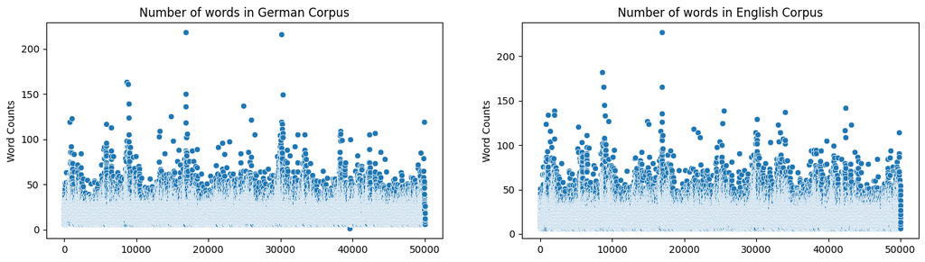

```python
fig, axes = plt.subplots(1,2,figsize=(16,4)); # Creating 10 subplots
ax=axes[0]
_=ax.set_title("Number of words in German Corpus")
_=ax.set_ylabel("Word Counts")
_=sns.scatterplot(x=data.index,y=data["word_count_German"],data=data,ax=ax)  # Scatter plot between reviews and word count in each review
# _=sns.move_legend(ax, title='Class Label Sentiment', loc='best')  # change the default title
ax=axes[1]
_=ax.set_title("Number of words in English Corpus")
_=ax.set_ylabel("Word Counts")
_=sns.scatterplot(x=data.index,y=data["word_count_English"],data=data,ax=ax)   # Scatter plot between reviews and word count in each review
# _=sns.move_legend(ax, title='Class Label Sentiment', loc='best')  # change the default title
```

[output not shown]

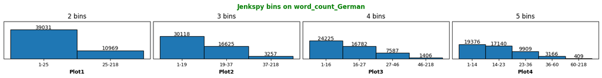

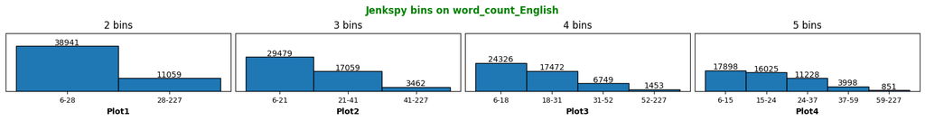

```python
%%time
import jenkspy
for wc_lan in ["word_count_German","word_count_English"]:
    cnt_lst=data[wc_lan].to_list()
    cnt_lst.sort()
    fig, axes = plt.subplots(1,4,figsize=(16,2),sharey=True, constrained_layout=True); # Creating 4 subplots
    for i in [2,3,4,5]:
        bins=i
        breaks = jenkspy.jenks_breaks(cnt_lst, n_classes=bins)
        # labels
        labels=[]
        ticks=[]
        for j in range(i):
            labels.append(str(breaks[j])+'-'+str(breaks[j+1]))
        data['bin_cut_break'] = pd.cut(cnt_lst , bins=breaks, labels=labels, include_lowest=True)
        ax=axes[i-2]
        _=ax.hist(data['bin_cut_break'],bins=bins,edgecolor="black")
        for p in ax.patches:
            x1 = p.get_x() + p.get_width() / 2
            y1 = p.get_y() + p.get_height() + .02*len(cnt_lst) # adjustment for label on top of bars
            _=ax.annotate(round(p.get_height()), (x1, y1), size = 10,ha="center")
            ticks.append(x1)
        _=ax.set_ylim([0, len(cnt_lst)]) # Number of records
        # _=ax.set_yticks(np.arange(0,21001,5000))
        _=ax.set_xticks(ticks)
        _=ax.set_yticks([])
        _=ax.set_xticklabels(labels, fontsize=9)
        _=ax.set_title(str(bins)+' bins');
        _=ax.set_xlabel('Plot'+str(i-1),fontsize=10,fontweight='bold')
        _=plt.suptitle("Jenkspy bins on "+wc_lan,color="green",fontweight="bold")
```

**Observations**

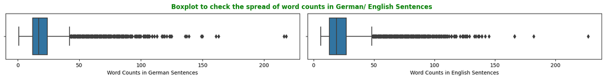

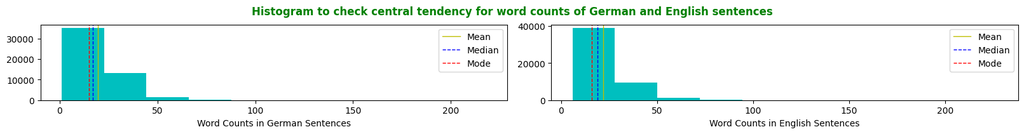

```python
fig, axes = plt.subplots(1, 2,figsize=(16,2),constrained_layout=True);
ax=axes[0]
_=sns.boxplot(x=data["word_count_German"],data=data,ax=axes[0]);
_=ax.set_xlabel('Word Counts in German Sentences');
ax=axes[1]
_=sns.boxplot(x=data["word_count_English"],data=data,ax=axes[1]);
_=ax.set_xlabel('Word Counts in English Sentences');
_=plt.suptitle("Boxplot to check the spread of word counts in German/ English Sentences ",color="green",fontweight="bold")
fig, axes = plt.subplots(1, 2,figsize=(16,2),constrained_layout=True);
ax=axes[0]
_=ax.hist(data["word_count_German"], color='c') # plots a simple histogram
_=ax.axvline(data["word_count_German"].mean(), color='y', linewidth=1,label ='Mean')
_=ax.axvline(data["word_count_German"].median(), color='b', linestyle='--', linewidth=1,label ='Median')
_=ax.axvline(data["word_count_German"].mode()[0], color='r', linestyle='--', linewidth=1,label ='Mode')
_=ax.legend()
_=ax.set_xlabel('Word Counts in German Sentences');
ax=axes[1]
_=ax.hist(data["word_count_English"], color='c') # plots a simple histogram
_=ax.axvline(data["word_count_English"].mean(), color='y', linewidth=1,label ='Mean')
_=ax.axvline(data["word_count_English"].median(), color='b', linestyle='--', linewidth=1,label ='Median')
_=ax.axvline(data["word_count_English"].mode()[0], color='r', linestyle='--', linewidth=1,label ='Mode')
_=ax.legend()
_=ax.set_xlabel('Word Counts in English Sentences');
_=plt.suptitle("Histogram to check central tendency for word counts of German and English sentences",color="green",fontweight="bold")
```

**Observations**

#### **Defining Source and Target Language**

```python
source_lan_="German"
target_lan_="English"
```